# PC2 - Minería de Datos

Francisco Andrade, Fernando Cortés, Ana Rosa Cajavilca y Anilda Guevara

2019-07-06

# 1. Esta pregunta debe responderse utilizando el conjunto de datos *Weekly*, que es parte del paquete ISLR.

## a. Produzca algunos resúmenes numéricos y gráficos de los datos semanales. ¿Parece que hay algún patrón?

El dataset Weekly presenta el porcentaje semanal de rendimientos para el índice de acciones Standard & Poor’s (S&P) 500. El índice se basa en la capitalización bursátil de 500 grandes empresas que cotizan en las bolsas de Nueva York (New York Stock Exchange abreviado NYSE) o la National Association of Securities Dealers Automated Quotation (NASDAQ), que es la segunda bolsa de valores automatizada y electrónica más grande de Estados Unidos.

El dataset Weekly contiene 1089 observaciones semanales tomadas durante 21 años, desde 1990 hasta el 2010, con las siguientes 9 variables:

- Year: El año en que se registró la observación.
- Lag1: Porcentaje de retorno de la semana anterior
- Lag2: Porcentaje de retorno para 2 semanas previas.
- Lag3: Porcentaje de retorno para las 3 semanas anteriores.
- Lag4: Porcentaje de retorno por 4 semanas previas.
- Lag5: Porcentaje de retorno durante las 5 semanas anteriores.
- Volumen: Volumen de acciones negociadas (número promedio de acciones diarias negociadas en miles de millones)
- Today: Porcentaje de retorno para esta semana.
- Direction: Un factor con niveles abajo y arriba que indica si el mercado tuvo un rendimiento positivo o negativo en una semana determinada.

```r
library(ISLR)
library(ggplot2)
library(knitr)
library(skimr)
library(ggpubr)
library(reshape2)
library(knitr)
library(dplyr)
library(data.table)
library(MASS)
library(class)
library(scatterplot3d)
library(GGally)
library(corrplot)
data("Weekly")
head(Weekly)
```

```
##   Year   Lag1   Lag2   Lag3   Lag4   Lag5    Volume  Today Direction
## 1 1990  0.816  1.572 -3.936 -0.229 -3.484 0.1549760 -0.270      Down
## 2 1990 -0.270  0.816  1.572 -3.936 -0.229 0.1485740 -2.576      Down
## 3 1990 -2.576 -0.270  0.816  1.572 -3.936 0.1598375  3.514        Up
## 4 1990  3.514 -2.576 -0.270  0.816  1.572 0.1616300  0.712        Up
## 5 1990  0.712  3.514 -2.576 -0.270  0.816 0.1537280  1.178        Up
## 6 1990  1.178  0.712  3.514 -2.576 -0.270 0.1544440 -1.372      Down
```

**A continuación mostramos un pequeño descriptivo de las variables:**

```r
# summary(Weekly)
skim(Weekly)
```

```
## Skim summary statistics
##  n obs: 1089
##  n variables: 9
##
## -- Variable type:factor -------------------------------------------------------------------------------------
##   variable missing complete    n n_unique               top_counts ordered
##  Direction       0     1089 1089        2 Up: 605, Dow: 484, NA: 0   FALSE
##
## -- Variable type:numeric ------------------------------------------------------------------------------------
##  variable missing complete    n    mean   sd       p0     p25     p50
##      Lag1       0     1089 1089    0.15 2.36  -18.2     -1.15    0.24
##      Lag2       0     1089 1089    0.15 2.36  -18.2     -1.15    0.24
##      Lag3       0     1089 1089    0.15 2.36  -18.2     -1.16    0.24
##      Lag4       0     1089 1089    0.15 2.36  -18.2     -1.16    0.24
##      Lag5       0     1089 1089    0.14 2.36  -18.2     -1.17    0.23
##     Today       0     1089 1089    0.15 2.36  -18.2     -1.15    0.24
##    Volume       0     1089 1089    1.57 1.69    0.087    0.33    1
##      Year       0     1089 1089 2000.05 6.03 1990     1995    2000
##      p75    p100     hist
##     1.4    12.03 ▁▁▁▁▇▆▁▁
##     1.41   12.03 ▁▁▁▁▇▆▁▁
##     1.41   12.03 ▁▁▁▁▇▆▁▁
##     1.41   12.03 ▁▁▁▁▇▆▁▁
##     1.4    12.03 ▁▁▁▁▇▆▁▁
##     1.4    12.03 ▁▁▁▁▇▆▁▁
##     2.05    9.33 ▇▃▁▁▁▁▁▁
##  2005    2010    ▇▇▆▇▅▇▆▇
```

Se observa que la data contiene información entre los años 1990 a 2010, siendo las medias y los percentiles de las variables “Lag” y “Today” bastante similares entre si (0.15 de media), lo cual indicara que los rendimientos entre semanas tienen una distribución bastante parecida. Para identificar algún patrón entre las variables del dataset analizaremos las correlaciones.

- **Análisis de correlación**

```r
cor_matrix <- round(cor(Weekly[,-9], method = "pearson" ), digits = 2)
cor_matrix[upper.tri(cor_matrix, diag = TRUE)] <- ""
as.data.frame(cor_matrix)
```

```
##         Year  Lag1  Lag2  Lag3  Lag4  Lag5 Volume Today
## Year
## Lag1   -0.03
## Lag2   -0.03 -0.07
## Lag3   -0.03  0.06 -0.08
## Lag4   -0.03 -0.07  0.06 -0.08
## Lag5   -0.03 -0.01 -0.07  0.06 -0.08
## Volume  0.84 -0.06 -0.09 -0.07 -0.06 -0.06
## Today  -0.03 -0.08  0.06 -0.07 -0.01  0.01  -0.03
```

La matriz de correlación indicaría una nula correlación entre las variables “Lag” con “Today”, lo cual indicaría que los rendimientos pasados no influyen en el rendimiento presente. Sin embargo, si se observa una alta correlación positiva entre “Year” con “Volume” esto puede interpretarse como que el volumen de acciones negociadas se ha incrementado a lo largo de los años, lo que se observa en el siguiente gráfico de serie de tiempo:

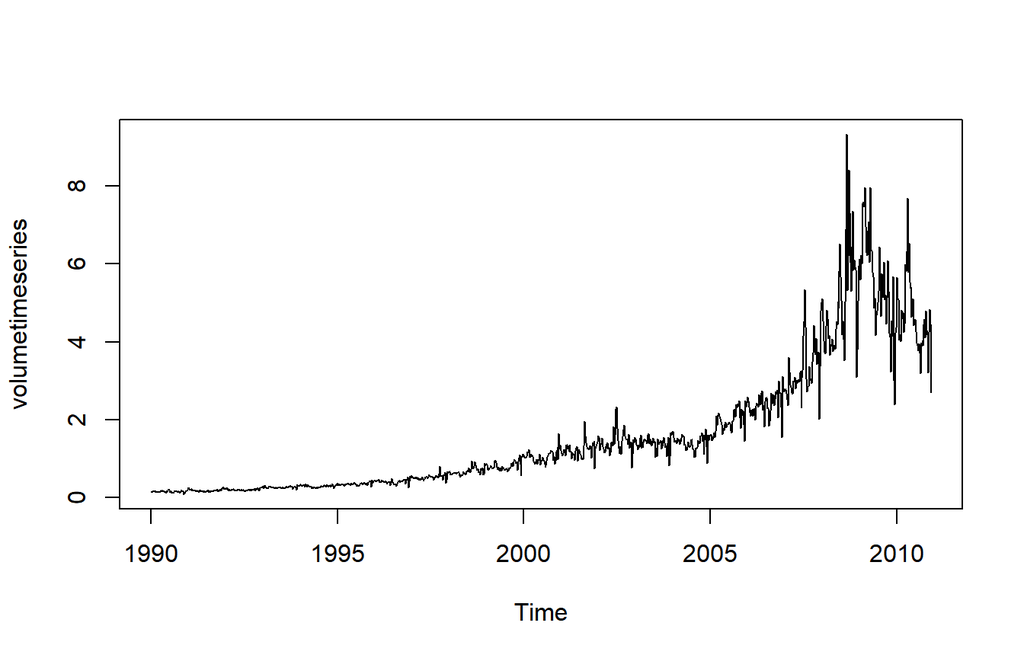

```r
volumetimeseries <- ts(Weekly$Volume, frequency=52, start=c(1990,1))
plot.ts(volumetimeseries)
```

- **Distribuciones de las variables “Lag”, “Today” y “Volume” según “Direction”**

Ahora, verificaremos las distribuciones de todas las variables según la variable respuesta “Direction” a fin de visualizar si existen distribuciones distintas entre poblaciones con diferentes direcciones:

Distribuciones de las variables según “Direction - Down”:

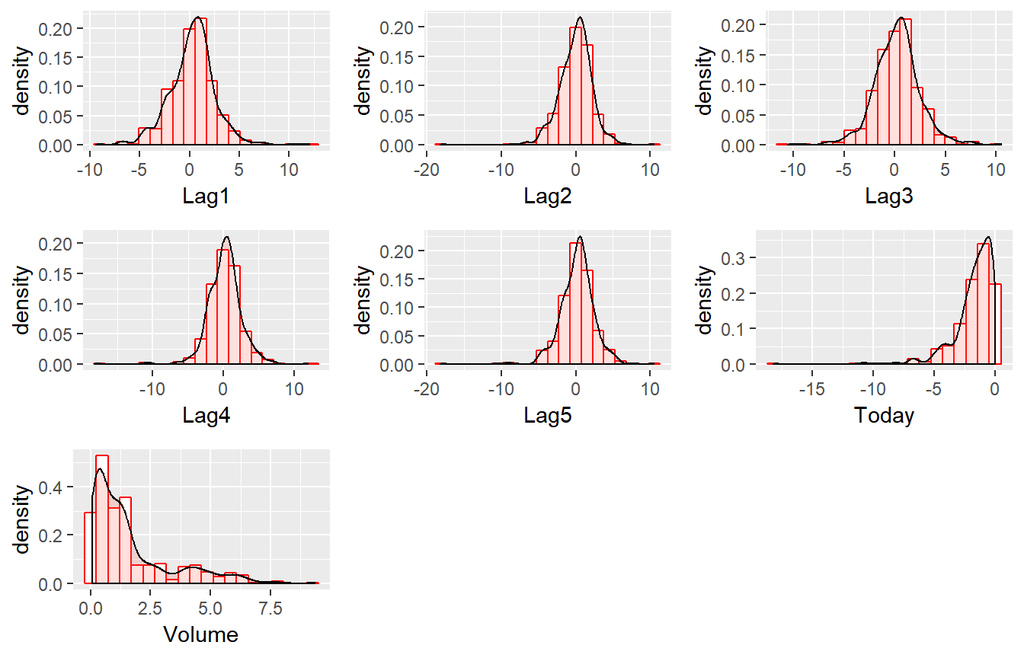

```r
x1.down=Weekly %>%
  filter(Direction=="Down") %>%
  ggplot(aes(Lag1)) +
  geom_histogram(aes(y=..density..), bins = 20, colour="red", fill="white")+
  geom_density(alpha=0.2, fill="#FF6655",position = "stack")

x2.down=Weekly %>%
  filter(Direction=="Down") %>%
  ggplot(aes(Lag2)) +
  geom_histogram(aes(y=..density..), bins = 20, colour="red", fill="white")+
  geom_density(alpha=0.2, fill="#FF6655",position = "stack")

x3.down=Weekly %>%
  filter(Direction=="Down") %>%
  ggplot(aes(Lag3)) +
  geom_histogram(aes(y=..density..), bins = 20, colour="red", fill="white")+
  geom_density(alpha=0.2, fill="#FF6655",position = "stack")

x4.down=Weekly %>%
  filter(Direction=="Down") %>%
  ggplot(aes(Lag4)) +
  geom_histogram(aes(y=..density..), bins = 20, colour="red", fill="white")+
  geom_density(alpha=0.2, fill="#FF6655",position = "stack")

x5.down=Weekly %>%
  filter(Direction=="Down") %>%
  ggplot(aes(Lag5)) +
  geom_histogram(aes(y=..density..), bins = 20, colour="red", fill="white")+
  geom_density(alpha=0.2, fill="#FF6655",position = "stack")

x6.down=Weekly %>%
  filter(Direction=="Down") %>%
  ggplot(aes(Today)) +
  geom_histogram(aes(y=..density..), bins = 20, colour="red", fill="white")+
  geom_density(alpha=0.2, fill="#FF6655",position = "stack")

x7.down=Weekly %>%
  filter(Direction=="Down") %>%
  ggplot(aes(Volume)) +
  geom_histogram(aes(y=..density..), bins = 20, colour="red", fill="white")+
  geom_density(alpha=0.2, fill="#FF6655",position = "stack")

ggarrange(x1.down,x2.down,x3.down,x4.down,x5.down,x6.down,x7.down, nrow = 3, ncol = 3)
```

Distribuciones de las variables según “Direction - Up”:

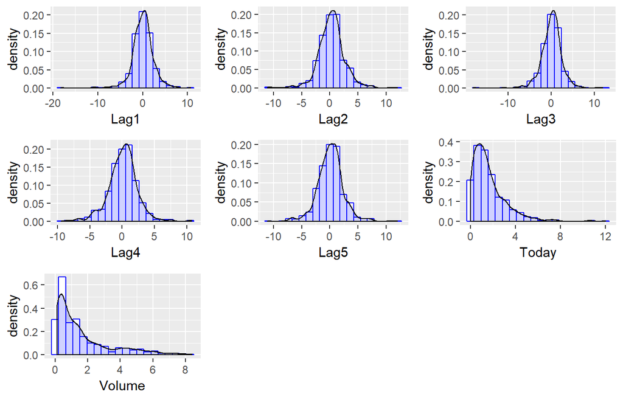

```r
x1.up=Weekly %>%
  filter(Direction=="Up") %>%
  ggplot(aes(Lag1)) +
  geom_histogram(aes(y=..density..), bins = 20, colour="blue", fill="white")+
  geom_density(alpha=0.2, fill="#141CFF",position = "stack")

x2.up=Weekly %>%
  filter(Direction=="Up") %>%
  ggplot(aes(Lag2)) +
  geom_histogram(aes(y=..density..), bins = 20, colour="blue", fill="white")+
  geom_density(alpha=0.2, fill="#141CFF",position = "stack")

x3.up=Weekly %>%
  filter(Direction=="Up") %>%
  ggplot(aes(Lag3)) +
  geom_histogram(aes(y=..density..), bins = 20, colour="blue", fill="white")+
  geom_density(alpha=0.2, fill="#141CFF",position = "stack")

x4.up=Weekly %>%
  filter(Direction=="Up") %>%
  ggplot(aes(Lag4)) +
  geom_histogram(aes(y=..density..), bins = 20, colour="blue", fill="white")+
  geom_density(alpha=0.2, fill="#141CFF",position = "stack")

x5.up=Weekly %>%
  filter(Direction=="Up") %>%
  ggplot(aes(Lag5)) +
  geom_histogram(aes(y=..density..), bins = 20, colour="blue", fill="white")+
  geom_density(alpha=0.2, fill="#141CFF",position = "stack")

x6.up=Weekly %>%
  filter(Direction=="Up") %>%
  ggplot(aes(Today)) +
  geom_histogram(aes(y=..density..), bins = 20, colour="blue", fill="white")+
  geom_density(alpha=0.2, fill="#141CFF",position = "stack")

x7.up=Weekly %>%
  filter(Direction=="Up") %>%
  ggplot(aes(Volume)) +
  geom_histogram(aes(y=..density..), bins = 20, colour="blue", fill="white")+
  geom_density(alpha=0.2, fill="#141CFF",position = "stack")

ggarrange(x1.up,x2.up,x3.up,x4.up,x5.up,x6.up,x7.up, nrow = 3, ncol = 3)
```

De acuerdo a los histogramas presentados, se observa que existe una especie de normalidad en la distribución en la mayoría de variables “Lag”. La cual deja de estar presente según “Direction” principalmente en las variables “Volume” y “Today”. Para verificar la normalidad del conjunto de datos, utilizaremos el qqplot para cada una de las variables y veremos si caen dentro del intervalo de confianza de los cuantiles de una normal:

- **Test de Normalidad de las variables - qqplot**

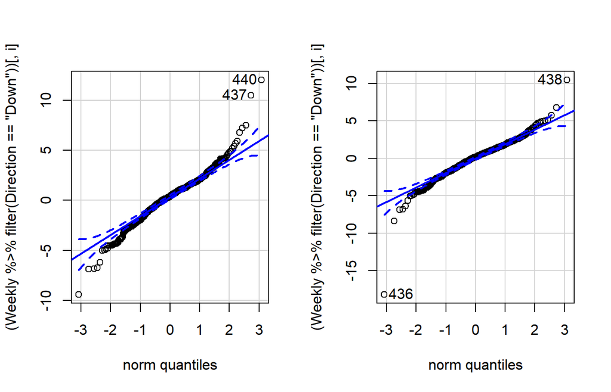

```r
library(car)
par(mfrow = c(1, 2))
for(i in 2:3){
  qqPlot((Weekly %>%
            filter(Direction=="Down"))[ , i])
}
```

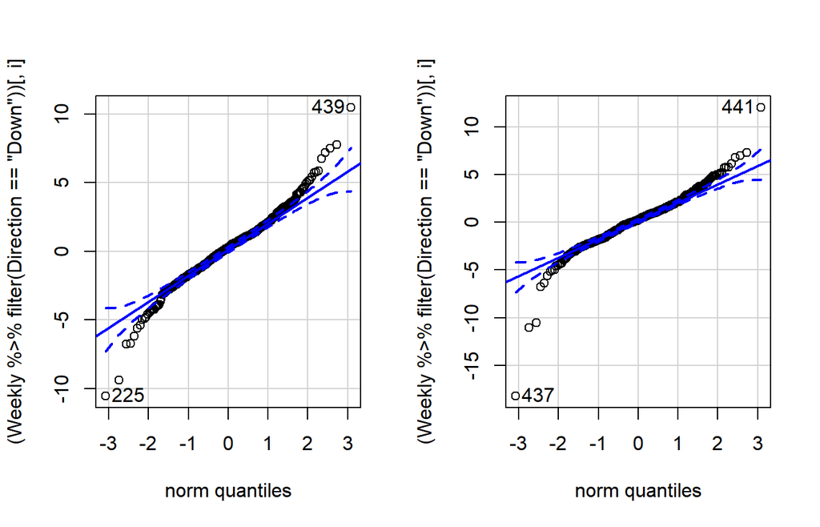

```r
par(mfrow = c(1, 2))
for(i in 4:5){
  qqPlot((Weekly %>%
            filter(Direction=="Down"))[ , i])
}
```

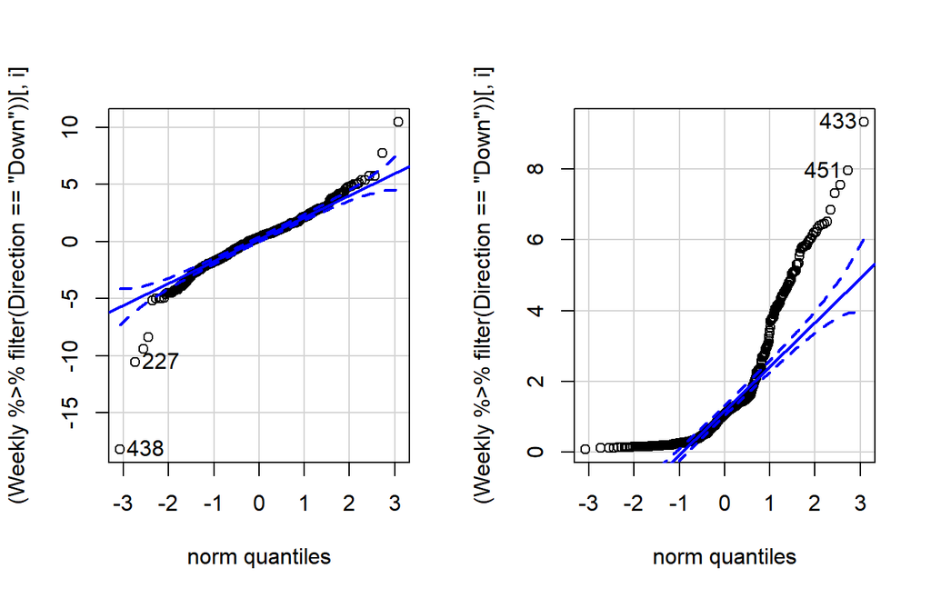

```r
par(mfrow = c(1, 2))
for(i in 6:7){
  qqPlot((Weekly %>%
            filter(Direction=="Down"))[ , i])
}
```

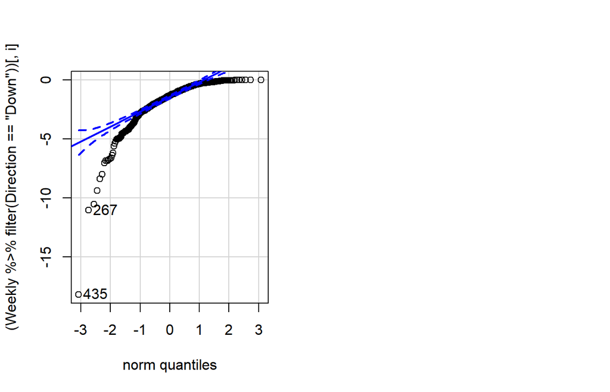

```r
par(mfrow = c(1, 2))
for(i in 8){
  qqPlot((Weekly %>%
            filter(Direction=="Down"))[ , i])
}
```

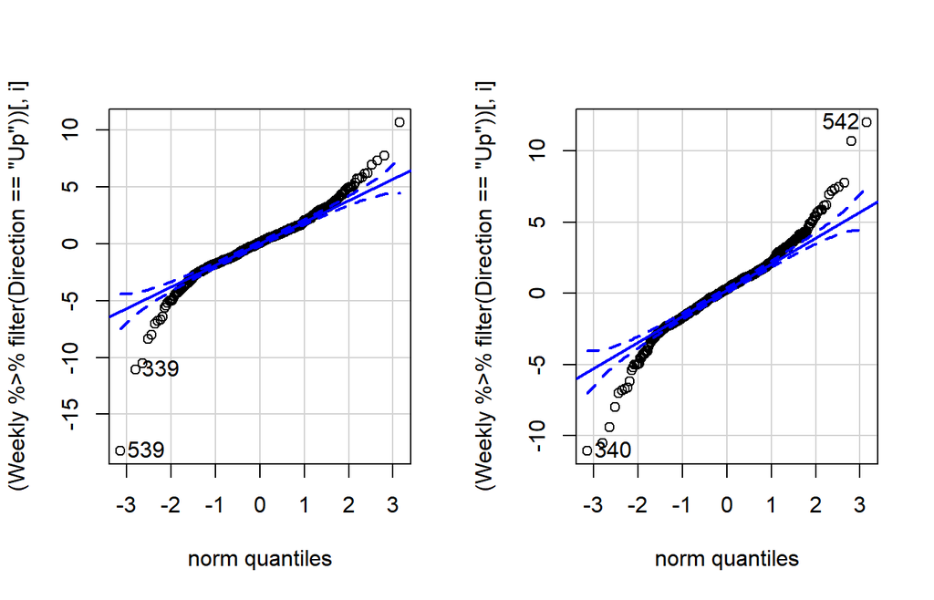

```r
library(car)
par(mfrow = c(1, 2))
for(i in 2:3){
  qqPlot((Weekly %>%
            filter(Direction=="Up"))[ , i])
}
```

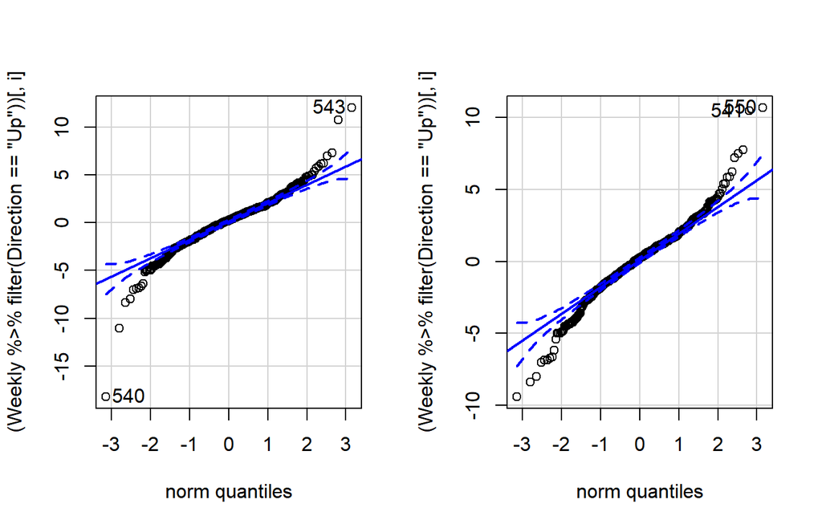

```r
par(mfrow = c(1, 2))
for(i in 4:5){
  qqPlot((Weekly %>%
            filter(Direction=="Up"))[ , i])
}
```

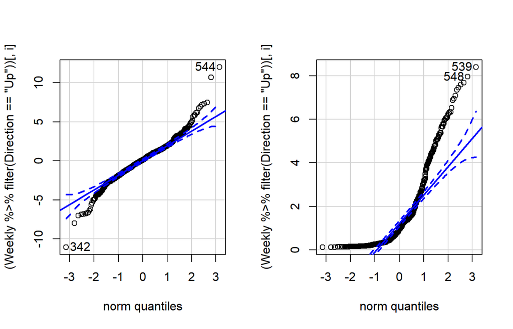

```r
par(mfrow = c(1, 2))
for(i in 6:7){
  qqPlot((Weekly %>%
            filter(Direction=="Up"))[ , i])
}
```

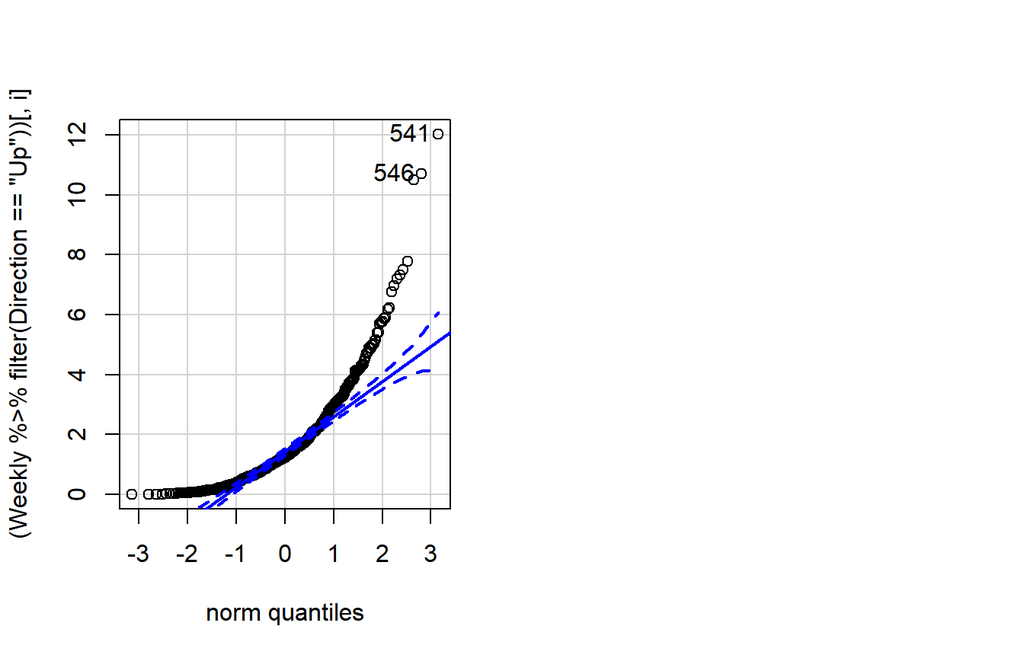

```r
par(mfrow = c(1, 2))
for(i in 8){
  qqPlot((Weekly %>%
            filter(Direction=="Up"))[ , i])
}
```

Se puede apreciar que en todas las gráficas hay observaciones que salen fuera de los intervalos de confianza, por lo que aparentemente no deberían ser distribuciones normales especialmente por las colas. Lo comprobaremos con el test de Shapiro Wilk.

- **Test de Normalidad de las variables - Shapiro Wilk**

```r
#Contraste de normalidad Shapiro-Wilk para cada variable en cada dirección
Weekly_tidy <- melt(Weekly[,-1], value.name = "valor")
Weekly_tidy=data.table(Weekly_tidy %>% group_by(Direction, variable) %>%
summarise(p_value_Shapiro.test = shapiro.test(valor)$p.value));Weekly_tidy
```

```
##     Direction variable p_value_Shapiro.test
##  1:      Down     Lag1         8.267335e-09
##  2:      Down     Lag2         4.921042e-14
##  3:      Down     Lag3         3.605212e-08
##  4:      Down     Lag4         5.699773e-15
##  5:      Down     Lag5         4.995664e-15
##  6:      Down   Volume         1.731765e-24
##  7:      Down    Today         2.962680e-26
##  8:        Up     Lag1         1.960518e-16
##  9:        Up     Lag2         1.878763e-12
## 10:        Up     Lag3         6.083897e-16
## 11:        Up     Lag4         1.289677e-10
## 12:        Up     Lag5         6.156961e-11
## 13:        Up   Volume         1.665561e-27
## 14:        Up    Today         1.066633e-25
```

Se observa que el p-value en todas variables según “Direction” es menor al nivel de significación de 0.05 por lo cual se rechaza la hipótesis de normalidad de las variables.

## b. Use el conjunto de datos completo para realizar una regresión logística con Direction como la respuesta y las cinco variables lag más el “Volume” como predictores. Use la función summary para imprimir los resultados. ¿Alguno de los predictores parece ser estadísticamente significativo? Si es así, ¿cuáles?

Antes de realizar el ajuste logístico, convertimos la variable de respuesta “Direction” en dicotómica:

```r
contrasts(Weekly$Direction)
```

```
##      Up
## Down  0
## Up    1
```

Aplicamos la regresión logística con la función “glm” con link “binomial”, para predecir la variable “Direction” considerando como covariables a las variables “Lag” y “Volume”, obteniéndose que sólo la variable “Lag 2” es significativa. Además, dado que el coeficiente estimado respecto a dicha variables es positivo, indica que si el rendimiento subió hace dos semanas, es más probable que la dirección del rendimiento sea “Up”.

```r
modelo_logistico <- glm(Direction ~ Lag1 + Lag2 + Lag3 + Lag4 + Lag5 + Volume, data = Weekly, family = "binomial")
summary(modelo_logistico)
```

```
##
## Call:
## glm(formula = Direction ~ Lag1 + Lag2 + Lag3 + Lag4 + Lag5 +
##     Volume, family = "binomial", data = Weekly)
##
## Deviance Residuals:
##     Min       1Q   Median       3Q      Max
## -1.6949  -1.2565   0.9913   1.0849   1.4579
##
## Coefficients:
##             Estimate Std. Error z value Pr(>|z|)
## (Intercept)  0.26686    0.08593   3.106   0.0019 **
## Lag1        -0.04127    0.02641  -1.563   0.1181
## Lag2         0.05844    0.02686   2.175   0.0296 *
## Lag3        -0.01606    0.02666  -0.602   0.5469
## Lag4        -0.02779    0.02646  -1.050   0.2937
## Lag5        -0.01447    0.02638  -0.549   0.5833
## Volume      -0.02274    0.03690  -0.616   0.5377
## ---
## Signif. codes:  0 '***' 0.001 '**' 0.01 '*' 0.05 '.' 0.1 ' ' 1
##
## (Dispersion parameter for binomial family taken to be 1)
##
##     Null deviance: 1496.2  on 1088  degrees of freedom
## Residual deviance: 1486.4  on 1082  degrees of freedom
## AIC: 1500.4
##
## Number of Fisher Scoring iterations: 4
```

```r
exp(coef(modelo_logistico))
```

```
## (Intercept)        Lag1        Lag2        Lag3        Lag4        Lag5
##   1.3058630   0.9595710   1.0601831   0.9840671   0.9725924   0.9856322
##      Volume
##   0.9775151
```

## c. Calcule e interprete la matriz de confusión de las predicciones correctas obtenido por una regresión logística.

- **Predicciones de la regresión logística ajustada en (b) con data total**

Con el modelo ajustado en (b) se realizan predicciones con la función “predict”. Mostramos la predicción de las 6 primeras observaciones

```r
predicciones <- predict(object = modelo_logistico, type = "response")
head(predicciones)
```

```
##         1         2         3         4         5         6
## 0.6086249 0.6010314 0.5875699 0.4816416 0.6169013 0.5684190
```

Para hallar el punto de corte óptimo comenzamos graficando la curva ROC

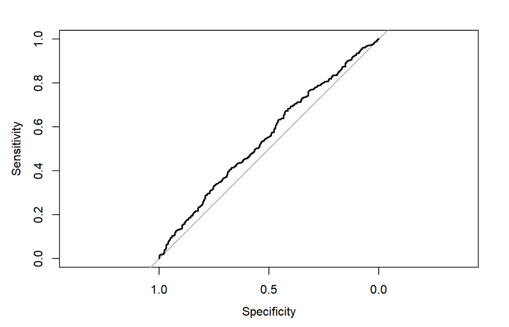

```r
library(pROC)
plot(roc(as.numeric(Weekly$Direction)-1, predicciones))
```

```r
roc(as.numeric(Weekly$Direction)-1, predicciones)
```

```
##
## Call:
## roc.default(response = as.numeric(Weekly$Direction) - 1, predictor = predicciones)
##
## Data: predicciones in 484 controls (as.numeric(Weekly$Direction) - 1 0) < 605 cases (as.numeric(Weekly$Direction) - 1 1).
## Area under the curve: 0.5537
```

Se puede apreciar que el nivel de diferenciación es bastante bajo (0.55 AUC), sacaremos la distribución de Down y Up para ver en qué percentil de las predicciones se asemeja a esa distribución:

```r
prop.table(table(Weekly[ , 9]))
```

```
##
##      Down        Up
## 0.4444444 0.5555556
```

Obtenemos el cuantil correspondiente a 0.444444

```r
(q <- quantile(predicciones, p = 0.4444444))
```

```
## 44.44444%
## 0.5515942
```

Utilizamos este valor como punto de corte

```r
prediccion <- data.frame(probabilidad = predicciones, clase = rep(NA,length(predicciones)))
prediccion[prediccion$probabilidad < q,"clase"] <- "Down"
prediccion[prediccion$probabilidad > q,"clase"] <- "Up"
head(prediccion)
```

```
##   probabilidad clase
## 1    0.6086249    Up
## 2    0.6010314    Up
## 3    0.5875699    Up
## 4    0.4816416  Down
## 5    0.6169013    Up
## 6    0.5684190    Up
```

Matriz de confusión del modelo logístico con data total:

```r
table(clase_real = Weekly$Direction,clase_predicha = prediccion$clase)
```

```
##           clase_predicha
## clase_real Down  Up
##       Down  231 253
##       Up    253 352
```

Accuracy del modelo logístico con data total:

```r
paste( "El % de acierto del modelo es",mean(prediccion$clase == Weekly$Direction),"lo cual indicaría un bajo nivel de acierto en la predicción")
```

```
## [1] "El % de acierto del modelo es 0.535353535353535 lo cual indicaría un bajo nivel de acierto en la predicción"
```

Error de predicción del modelo logístico con data total:

```r
paste( "El % de error de predicción del modelo es",mean(prediccion$clase != Weekly$Direction))
```

```
## [1] "El % de error de predicción del modelo es 0.464646464646465"
```

Sensitividad y Especificidad:

```r
paste( "La sensitividad del modelo es:",(352/(352+253)))
```

```
## [1] "La sensitividad del modelo es: 0.581818181818182"
```

```r
paste( "La especificidad del modelo es:",(231/(231+253)))
```

```
## [1] "La especificidad del modelo es: 0.477272727272727"
```

Estos indicadores nos dicen que efectivamente el modelo no es bueno para realizar predicciones, pues prácticamente está asignando aleatoriamente la dirección Up o Down. Sin embargo, debemos tener en cuenta que las predicciones fueron realizadas con un modelo con variables no significativas y con la totalidad de las observaciones.